# Cancer Study

Dillon Hector, Chenxi Su,Zeng

3/25/2020

Does cancer and death rate due to cancer change between US States. I am going to research this simple question to learn if there is a difference and if so, does population account for the change? This topic is important personally because many of my family memebers have died due to cancer and I am interested in learning more about the topic.

```r
#Adding the needed packages
library(DataComputing)
library(ggplot2)
library(tidyverse)
library(dplyr)
library(readxl)
library(usmap)
library(dplyr)
```

```r
#Importing the needed datasets
cancerincedents <- read_excel("~/Downloads/adamhelsinger-cancer-rates-by-u-s-state/data/uscs_map_incidence_all.xlsm")
```

```
-
/
```

```r
cancerdeaths <- read_excel("~/Downloads/adamhelsinger-cancer-rates-by-u-s-state/data/uscs_map_death_all.xlsm")
```

```
-
/
```

```r
statepop <- read_excel("~/Downloads/State Populations.xlsm")
```

```
-
/
```

```r
stateabbrev <-read_excel("~/Downloads/data (1).xlsm")
```

```
-
/
```

```r
statesGDP <- read_excel("~/Downloads/download (1).xls", col_types =  c("text", "numeric"))
```

[output not shown]

[output not shown]

```r
#The first task that needs to be done is to wranglet the datasets togetheer into one dataset
#The first wrangle will be to join stateabbrev with statepop
statepopcorrected <-
  statepop %>%
  left_join(stateabbrev, by = "State")
#Now I will delete the variable "Abbrev"
statepopcorrected2 <- statepopcorrected[,-3]
#Here is the resulting table
statepopcorrected2
```

| State | 2018 Population | Code |
| --- | --- | --- |
| California | 39776830 | CA |
| Texas | 28704330 | TX |
| Florida | 21312211 | FL |
| New York | 19862512 | NY |
| Pennsylvania | 12823989 | PA |
| Illinois | 12768320 | IL |
| Ohio | 11694664 | OH |
| Georgia | 10545138 | GA |
| North Carolina | 10390149 | NC |
| Michigan | 9991177 | MI |

[output cut: 41 more lines]

```r
#I am not fond with the variable name "X2018.Population" so I will change that now
FinalStatepop <-
       statepopcorrected2 %>%
       rename(StatePop = "2018 Population")%>%
       rename(state = "State")
FinalStatepop
```

| state | StatePop | Code |
| --- | --- | --- |
| California | 39776830 | CA |
| Texas | 28704330 | TX |
| Florida | 21312211 | FL |
| New York | 19862512 | NY |
| Pennsylvania | 12823989 | PA |
| Illinois | 12768320 | IL |
| Ohio | 11694664 | OH |
| Georgia | 10545138 | GA |
| North Carolina | 10390149 | NC |
| Michigan | 9991177 | MI |

[output cut: 41 more lines]

```r
NA
```

```r
#Now I am going to rename the variables in cancer incidents and deaths to be more informative
CancerIncedents2 <-
  cancerincedents %>%
  rename(cancerrate = rate) %>%
  select(state, cancerrate)
CancerIncedents2
```

| state | cancerrate |
| --- | --- |
| AK | 406.6 |
| AL | 437.9 |
| AR | 456.2 |
| AZ | 379.8 |
| CA | 399.6 |
| CO | 395.8 |
| CT | 467.0 |
| DC | 442.4 |
| DE | 488.1 |
| FL | 410.0 |

[output cut: 41 more lines]

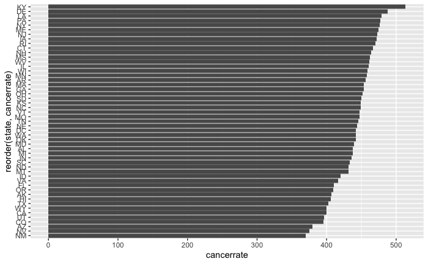

```r
#visuizling the cancer rate to see which one is the highest cancer rate
ggplot(data = CancerIncedents2, mapping = aes(x = reorder(state, cancerrate), cancerrate)) +
  geom_bar(stat = "identity") + coord_flip()
```

```r
#I am now going to do the same task I did above but with cancerdeaths dataset
CancerDeaths2 <-
  cancerdeaths %>%
  rename(deathrate = rate) %>%
  select(state, deathrate)
CancerDeaths2
```

| state | deathrate |
| --- | --- |
| AK | 173.1 |
| AL | 182.1 |
| AR | 189.6 |
| AZ | 146.4 |
| CA | 146.6 |
| CO | 139.2 |
| CT | 147.8 |
| DC | 177.7 |
| DE | 167.1 |
| FL | 154.9 |

[output cut: 41 more lines]

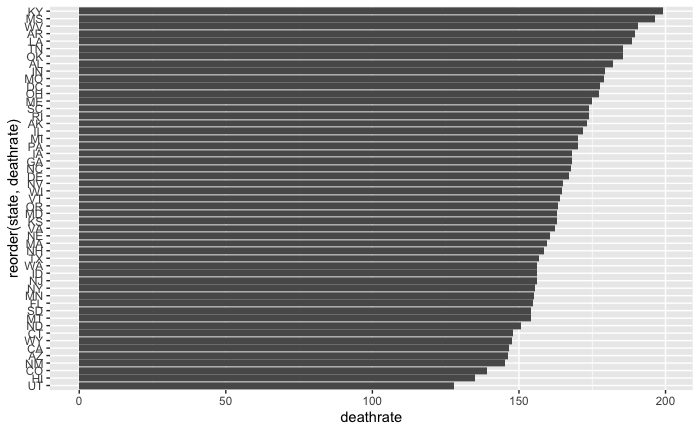

```r
#visuizling the death rate to see which one is the highest death rate
ggplot(data = CancerDeaths2, mapping = aes(x = reorder(state, deathrate), deathrate)) +
  geom_bar(stat = "identity") + coord_flip()
```

KY has the most cancer and death rate out of these states.

```r
#removing the first row (us sum GDP) that is not needed
statesGDPnew <-
statesGDP %>%
  filter(row_number() > 1) %>%
  rename(gdp = "GDP(MM)")
head(statesGDPnew)
```

| state | gdp |
| --- | --- |
| Alabama | 198435.9 |
| Alaska | 53092.4 |
| Arizona | 311705.6 |
| Arkansas | 117293.8 |
| California | 2721651.0 |
| Colorado | 341076.7 |

```r
names(somkingdata)<-str_replace_all(names(somkingdata), c(" " = "." , "," = "" ))
```

[output not shown]

[output not shown]

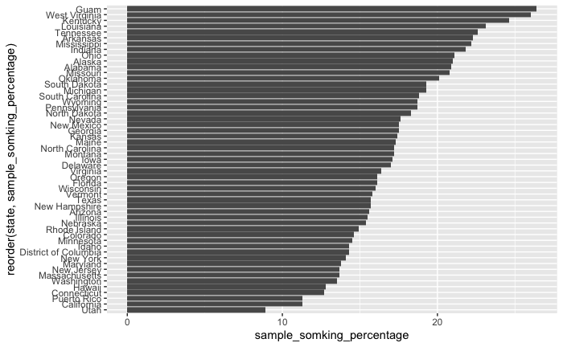

```r
#visuizling the somking rate to see which one is the highest somking rate
ggplot(data = somkingdata, mapping = aes(x = reorder(state, sample_somking_percentage), sample_somking_percentage)) +
  geom_bar(stat = "identity") + coord_flip()
```

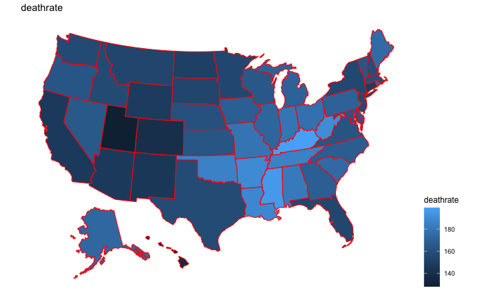

```r
#visuallizing the popluation, cancer rate & death rate in US Map
#purpose: to scan through comparsion to see if they are associated
plot_usmap(data = CancerDeaths2, values = "deathrate", color = "red") +
  scale_fill_continuous(name = "deathrate", label = scales::comma) +
   labs(title = "deathrate") +
  theme(legend.position = "right")
```

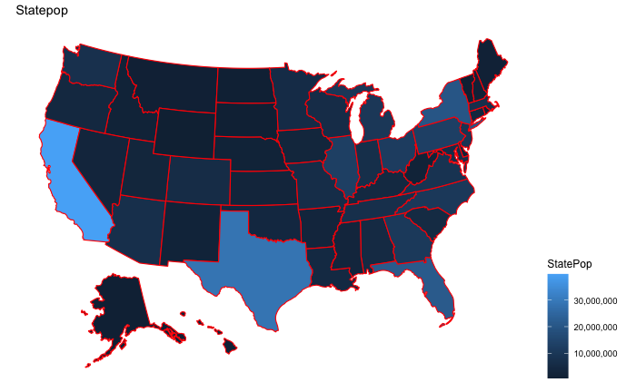

```r
plot_usmap(data = FinalStatepop, values = "StatePop", color = "red") +
  scale_fill_continuous(name = "StatePop", label = scales::comma) +
  labs(title = "Statepop") +
  theme(legend.position = "right")
```

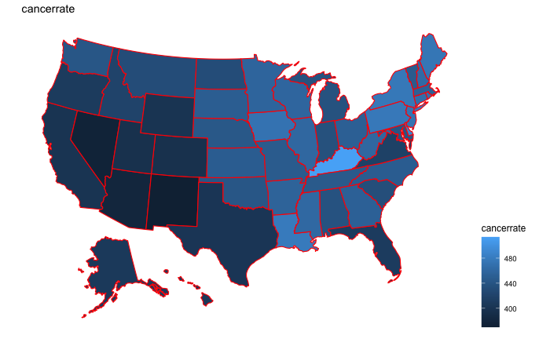

```r
plot_usmap(data = CancerIncedents2, values = "cancerrate", color = "red") +
  scale_fill_continuous(name = "cancerrate", label = scales::comma) +
  labs(title = "cancerrate") +
  theme(legend.position = "right")
```

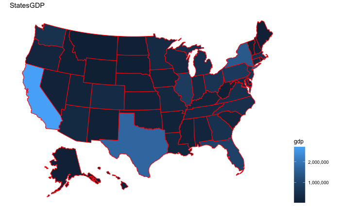

```r
plot_usmap(data = statesGDPnew, values = "gdp", color = "red") +
  scale_fill_continuous(name = "gdp", label = scales::comma) +
  labs(title = "StatesGDP") +
  theme(legend.position = "right")
```

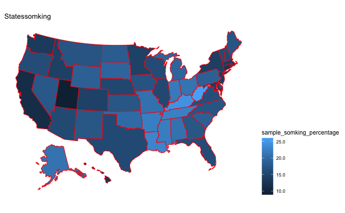

```r
plot_usmap(data = somkingdata, values = "sample_somking_percentage", color = "red") +
  scale_fill_continuous(name = "sample_somking_percentage", label = scales::comma) +
  labs(title = "Statessomking") +
  theme(legend.position = "right")
```

From the rough observation of these graph, the cancer rate and death rate seems to have correlation and population & GDP seems to have correlation. But we don’t see cancer rate haas anything to do with population or GDP, somking seems to be an factor casues high cancer rate, we are trying to have more detailed analysis below….

```r
#I am now going to join the CancerIncidents2 and CancerDeaths2 dataset together
CancerData <-
  CancerIncedents2 %>%
  left_join(CancerDeaths2, by = "state")
CancerData
```

| state | cancerrate | deathrate |
| --- | --- | --- |
| AK | 406.6 | 173.1 |
| AL | 437.9 | 182.1 |
| AR | 456.2 | 189.6 |
| AZ | 379.8 | 146.4 |
| CA | 399.6 | 146.6 |
| CO | 395.8 | 139.2 |
| CT | 467.0 | 147.8 |
| DC | 442.4 | 177.7 |
| DE | 488.1 | 167.1 |
| FL | 410.0 | 154.9 |

[output cut: 41 more lines]

```r
#Finally we will join the CancerData with the FinalStatePop Data
Cancer <-
  FinalStatepop %>%
  select(state, StatePop, Code) %>%
  left_join(CancerData, by = c("Code" = "state")) %>%
  left_join(statesGDPnew) %>%
  left_join(somkingdata)
Cancer
```

| state | StatePop | Code | cancerrate | deathrate | gdp | sample_somking_percentage |
| --- | --- | --- | --- | --- | --- | --- |
| California | 39776830 | CA | 399.6 | 146.6 | 2721651.0 | 11.3 |
| Texas | 28704330 | TX | 402.2 | 156.9 | 1712764.0 | 15.7 |
| Florida | 21312211 | FL | 410.0 | 154.9 | 924873.3 | 16.1 |
| New York | 19862512 | NY | 476.5 | 155.5 | 1435636.2 | 14.1 |
| Pennsylvania | 12823989 | PA | 477.3 | 170.0 | 711822.2 | 18.7 |
| Illinois | 12768320 | IL | 460.4 | 171.7 | 769800.6 | 15.5 |
| Ohio | 11694664 | OH | 452.1 | 177.4 | 605394.6 | 21.1 |
| Georgia | 10545138 | GA | 453.4 | 168.1 | 528998.9 | 17.5 |
| North Carolina | 10390149 | NC | 448.8 | 167.7 | 497331.3 | 17.2 |
| Michigan | 9991177 | MI | 437.3 | 170.2 | 470529.2 | 19.3 |

[output cut: 41 more lines]

```r
#I am now going to create a new variable that gives the percentage of deathrate
Cancer <-
Cancer %>%
  mutate(deathpercent = deathrate/cancerrate) %>%
  arrange(desc(deathpercent))
Cancer
```

| state | StatePop | Code | cancerrate | deathrate | gdp | sample_somking_percentage | deathpercent |
| --- | --- | --- | --- | --- | --- | --- | --- |
| Nevada | 3056824 | NV | 374.9 | 164.9 | 149779.9 | 17.6 | 0.4398506 |
| Alaska | 738068 | AK | 406.6 | 173.1 | 53092.4 | 21.0 | 0.4257255 |
| Mississippi | 2982785 | MS | 462.1 | 196.5 | 102837.4 | 22.2 | 0.4252326 |
| Oklahoma | 3940521 | OK | 442.0 | 185.4 | 196524.6 | 20.1 | 0.4194570 |
| Tennessee | 6782564 | TN | 445.7 | 185.4 | 323674.9 | 22.6 | 0.4159749 |
| Alabama | 4888949 | AL | 437.9 | 182.1 | 198435.9 | 20.9 | 0.4158484 |
| Arkansas | 3020327 | AR | 456.2 | 189.6 | 117293.8 | 22.3 | 0.4156072 |
| West Virginia | 1803077 | WV | 461.0 | 190.5 | 71481.4 | 26.0 | 0.4132321 |
| Indiana | 6699629 | IN | 435.8 | 179.4 | 329298.8 | 21.8 | 0.4116567 |
| District of Columbia | 703608 | DC | 442.4 | 177.7 | 123981.6 | 14.3 | 0.4016727 |

[output cut: 41 more lines]

```r
Cancer %>%
  summarise(MeanCancer = mean(cancerrate), MeanDeaths = mean(deathrate)) %>%
  mutate(meandeathrate = MeanDeaths/MeanCancer)
```

| MeanCancer | MeanDeaths | meandeathrate |
| --- | --- | --- |
| 440.4235 | 165.0863 | 0.3748353 |

We can see above that Nevada has the highest deaths per cancer patient. This is odd seeing how the population is not the largest by far and the cancer rate is below the mean cancer rate across all states which is shown above. The death rate is about average though which is probably why the percentage is so high.

```r
#I am going to round the numbers in death percent
Cancer <-
  Cancer %>%
  mutate(deathpercent = round(deathpercent, digits = 2))

Cancer
```

| state | StatePop | Code | cancerrate | deathrate | gdp | sample_somking_percentage | deathpercent |
| --- | --- | --- | --- | --- | --- | --- | --- |
| Nevada | 3056824 | NV | 374.9 | 164.9 | 149779.9 | 17.6 | 0.44 |
| Alaska | 738068 | AK | 406.6 | 173.1 | 53092.4 | 21.0 | 0.43 |
| Mississippi | 2982785 | MS | 462.1 | 196.5 | 102837.4 | 22.2 | 0.43 |
| Oklahoma | 3940521 | OK | 442.0 | 185.4 | 196524.6 | 20.1 | 0.42 |
| Tennessee | 6782564 | TN | 445.7 | 185.4 | 323674.9 | 22.6 | 0.42 |
| Alabama | 4888949 | AL | 437.9 | 182.1 | 198435.9 | 20.9 | 0.42 |
| Arkansas | 3020327 | AR | 456.2 | 189.6 | 117293.8 | 22.3 | 0.42 |
| West Virginia | 1803077 | WV | 461.0 | 190.5 | 71481.4 | 26.0 | 0.41 |
| Indiana | 6699629 | IN | 435.8 | 179.4 | 329298.8 | 21.8 | 0.41 |
| District of Columbia | 703608 | DC | 442.4 | 177.7 | 123981.6 | 14.3 | 0.40 |

[output cut: 41 more lines]

```r
#I am now going to create a dataframe that will let me make me see the states with each death percent
Cancer2 <-
  Cancer %>%
  select(state, deathpercent) %>%
  arrange(desc(deathpercent))
Cancer2
```

| state | deathpercent |
| --- | --- |
| Nevada | 0.44 |
| Alaska | 0.43 |
| Mississippi | 0.43 |
| Oklahoma | 0.42 |
| Tennessee | 0.42 |
| Alabama | 0.42 |
| Arkansas | 0.42 |
| West Virginia | 0.41 |
| Indiana | 0.41 |
| District of Columbia | 0.40 |

[output cut: 41 more lines]

```r
#Now that we have the new data table I am going to spread the table with State
Cancer2 <-
  Cancer2 %>%
  spread(key = state, value = deathpercent)
Cancer2
```

| Alabama | Alaska | Arizona | Arkansas | California | Colorado | Connecticut | Delaware | District of Columbia | Florida | Georgia | Hawaii | Idaho | Illinois | Indiana | Iowa | Kansas | Kentucky | Louisiana | Maine | Maryland | Massachusetts | Michigan | Minnesota | Mississippi | Missouri | Montana | Nebraska | Nevada | New Hampshire | … |
| --- | --- | --- | --- | --- | --- | --- | --- | --- | --- | --- | --- | --- | --- | --- | --- | --- | --- | --- | --- | --- | --- | --- | --- | --- | --- | --- | --- | --- | --- | --- |
| 0.42 | 0.43 | 0.39 | 0.42 | 0.37 | 0.35 | 0.32 | 0.34 | 0.4 | 0.38 | 0.37 | 0.33 | 0.37 | 0.37 | 0.41 | 0.36 | 0.36 | 0.39 | 0.39 | 0.37 | 0.37 | 0.35 | 0.39 | 0.34 | 0.43 | 0.4 | 0.36 | 0.36 | 0.44 | 0.34 | … |

Looking above we can easily see the death percents for each state. The table has been layed out so you can see the information very easily for your chosen state. The states are also in alphabetical order now so it is also easier to find your state.

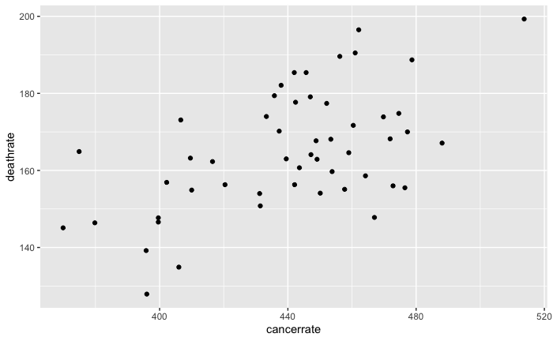

```r
#Now we will look at some plots to see if we can see a relationship between the variables
#First we will look at State vs Cancer rate plot
Cancer %>%
  ggplot(aes(x = cancerrate, y = deathrate)) +
  geom_point()
```

```r
NA
NA
```

We can see above that as the cancer rate increases so does the death rate. There is a noticeable linear relationship between the two.

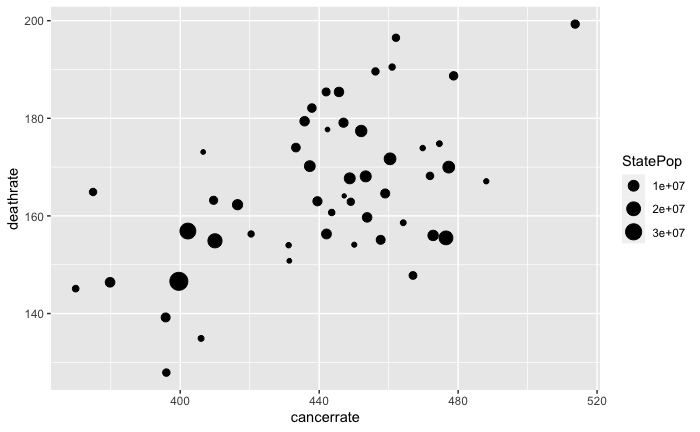

```r
#Now I am going to add population into the graph to see if population effects the cancer and/or death rate.
Cancer %>%
  ggplot(aes(x = cancerrate, y = deathrate)) +
  geom_point(aes(size = StatePop))
```

Although there are a few outliers we can see that most states fall into the middle range of population and that most of the larger populated states fall into the lower end of cancer and death rate.

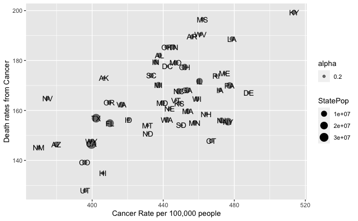

```r
#Now I am going to add State into the graph to specify which states are the outliers
Cancer %>%
  ggplot(aes(x = cancerrate, y = deathrate)) +
  geom_point(aes(size = StatePop, alpha = .2)) +
  geom_text(aes(label = Code)) +
  xlab("Cancer Rate per 100,000 people") +
  ylab("Death rates from Cancer")
```

We can see on the graph above that the outlier that was talked about in the previous segment is in fact Kentucky which has a small population but a high cancer rate and death rate. We can see that most of the states fall between the 440-480 Cancer rate range and that most states also fall between 150-180 cancer related deaths. There are some outliers but I don’t really think there is enough evidence to assume that different states have a dramtically different cancer rate and the population count also doesn’t seem to effect the rate either.

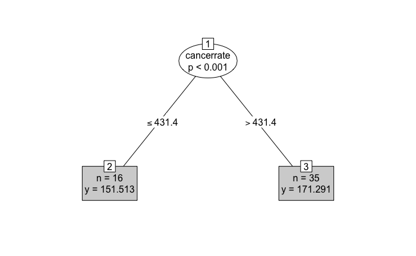

```r
ctreefunc <- party::ctree(deathrate ~ cancerrate + StatePop, data = Cancer)
plot(ctreefunc, type = "simple")
```

```r
head(Cancer)
```

[output not shown]

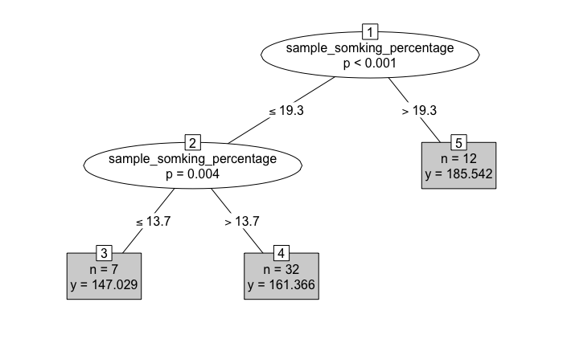

```r
mod1 <- party::ctree(deathrate ~ gdp + sample_somking_percentage, data = Cancer)
plot(mod1, type = "simple")
```

```r
Cancer %>%
  mutate(probability = as.numeric(predict(mod1)),
         likelihood = ifelse(deathrate, probability, 1-probability)) %>%
  summarise(log_likelihood = sum(log(likelihood)))
```

| log_likelihood |
| --- |
| 260.2913 |

```r
regressMod <- lm(deathrate ~ cancerrate + StatePop + gdp + sample_somking_percentage, data = Cancer )
regressMod$coefficients
```

```
              (Intercept)                cancerrate                  StatePop
             2.805389e+01              1.856138e-01              2.249399e-07
                      gdp sample_somking_percentage
            -1.138122e-06              3.141087e+00
```